# Demand Forecasting with Advanced Time Series Models

I use a monthly demand dataset (1990-2023, 408 points) containing pre-decomposed components (Trend, Cyclical, Seasonal, Irregular) to:

- Compare ARIMA, SARIMA, and Prophet models.
- Provide business-relevant forecasting insights.
- Highlight how to choose the right model for real-world decisions.

```
<class 'pandas.core.frame.DataFrame'>
DatetimeIndex: 408 entries, 1990-01-01 to 2023-12-01
Data columns (total 5 columns):
 #   Column     Non-Null Count  Dtype
---  ------     --------------  -----
 0   Demand     408 non-null    float64
 1   Trend      408 non-null    float64
 2   Cyclical   408 non-null    float64
 3   Seasonal   408 non-null    float64
 4   Irregular  408 non-null    float64
dtypes: float64(5)
memory usage: 19.1 KB
None
```

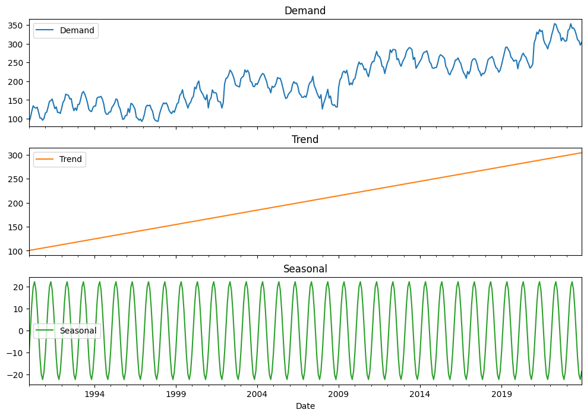

```python
import pandas as pd
import numpy as np
import matplotlib.pyplot as plt

df = pd.read_csv('/Users/jack/Desktop/MBA/etc/data/demand_forecast_assignment.csv', parse_dates=['Date'], index_col='Date')
print(df.info())

df[['Demand', 'Trend', 'Seasonal']].plot(subplots=True, figsize=(12, 8), title=['Demand', 'Trend', 'Seasonal'])
plt.show()
```

```python
# Check for negatives or anomalies
print("Negative values:\n", (df < 0).sum())

# For robustness, clip negatives to zero (if any)
df['Demand'] = df['Demand'].clip(lower=0)

# Check missing
print("Missing values:\n", df.isnull().sum())
```

```
Negative values:
 Demand         0
Trend          0
Cyclical     180
Seasonal     204
Irregular    217
dtype: int64
Missing values:
 Demand       0
Trend        0
Cyclical     0
Seasonal     0
Irregular    0
dtype: int64
```

### Baseline ARIMA Modeling

```
                               SARIMAX Results
==============================================================================
Dep. Variable:                 Demand   No. Observations:                  408
Model:                 ARIMA(1, 1, 1)   Log Likelihood               -1574.814
Date:                Thu, 08 May 2025   AIC                           3155.627
Time:                        13:32:26   BIC                           3167.654
Sample:                    01-01-1990   HQIC                          3160.387
                         - 12-01-2023
Covariance Type:                  opg
==============================================================================
                 coef    std err          z      P>|z|      [0.025      0.975]
------------------------------------------------------------------------------
ar.L1          0.4992      0.175      2.852      0.004       0.156       0.842
ma.L1         -0.2565      0.183     -1.402      0.161      -0.615       0.102
sigma2       134.3656      6.433     20.887      0.000     121.757     146.974
===================================================================================
Ljung-Box (L1) (Q):                   0.77   Jarque-Bera (JB):                98.98
Prob(Q):                              0.38   Prob(JB):                         0.00
Heteroskedasticity (H):               1.03   Skew:                             0.36
Prob(H) (two-sided):                  0.87   Kurtosis:                         5.30
===================================================================================

Warnings:
[1] Covariance matrix calculated using the outer product of gradients (complex-step).
```

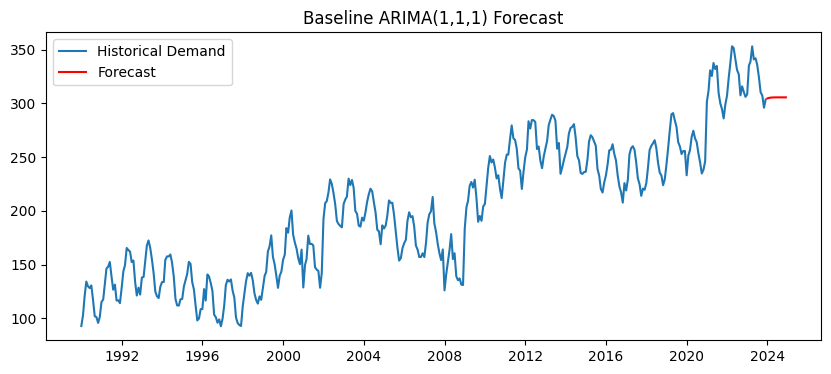

```python
import statsmodels.api as sm

model = sm.tsa.ARIMA(df['Demand'], order=(1,1,1))
result = model.fit()

print(result.summary())

forecast = result.forecast(steps=12)

plt.figure(figsize=(10, 4))
plt.plot(df['Demand'], label='Historical Demand')
plt.plot(forecast.index, forecast, label='Forecast', color='red')
plt.title('Baseline ARIMA(1,1,1) Forecast')
plt.legend()
plt.show()
```

### Baseline ARIMA(1,1,1) Summary

- **AIC 3155, BIC 3167:** Decent fit, balancing accuracy vs. complexity.
- **Coefficients:** AR(1)=0.499, MA(1)= -0.256 → moderate autocorrelation, mild negative MA effect.
- **Residual diagnostics:** Slight non-normality (high kurtosis), some unexplained structure.

Baseline ARIMA is a good starting point but lacks seasonality or external drivers. ➡ Next: Upgrade to SARIMA/SARIMAX for richer patterns.

[output not shown]

[output cut: 9 more lines]

```
------------------------------------------------------------------------------
ar.L1         -0.1207      0.154     -0.785      0.432      -0.422       0.181
ma.L1         -0.2433      0.156     -1.557      0.119      -0.550       0.063
ar.S.L12      -0.1664      0.037     -4.502      0.000      -0.239      -0.094
ma.S.L12      -0.9553      0.057    -16.887      0.000      -1.066      -0.844
sigma2        67.0579      3.470     19.328      0.000      60.258      73.858
===================================================================================
Ljung-Box (L1) (Q):                   0.00   Jarque-Bera (JB):               954.46
Prob(Q):                              0.98   Prob(JB):                         0.00
Heteroskedasticity (H):               0.94   Skew:                             0.25
Prob(H) (two-sided):                  0.74   Kurtosis:                        10.60
===================================================================================

Warnings:
[1] Covariance matrix calculated using the outer product of gradients (complex-step).
```

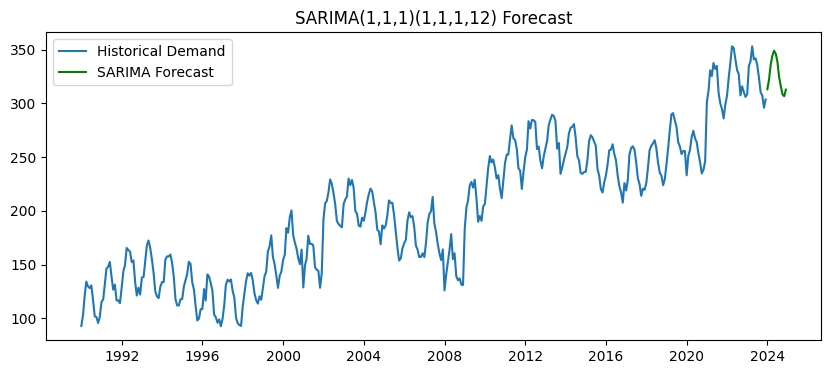

```python
sarima_model = sm.tsa.SARIMAX(df['Demand'],
                              order=(1,1,1),
                              seasonal_order=(1,1,1,12))
sarima_result = sarima_model.fit()

print(sarima_result.summary())

sarima_forecast = sarima_result.forecast(steps=12)

plt.figure(figsize=(10, 4))
plt.plot(df['Demand'], label='Historical Demand')
plt.plot(sarima_forecast.index, sarima_forecast, label='SARIMA Forecast', color='green')
plt.title('SARIMA(1,1,1)(1,1,1,12) Forecast')
plt.legend()
plt.show()
```

## SARIMA(1,1,1)(1,1,1,12) Summary

- Seasonal ARIMA captures monthly seasonality (12-period cycle), improving fit over baseline ARIMA.
- AIC: 2824.8 (lower than ARIMA’s 3155) → better balance of fit vs. complexity.
- Significant seasonal coefficients: ar.S.L12 (-0.166), ma.S.L12 (-0.955) → strong seasonal effects.
- Residual diagnostics: High kurtosis (10.6), non-normal residuals → still some unexplained variance.
- Convergence: L-BFGS-B optimizer successfully minimized the likelihood function.

➡ **Next step:** Test SARIMAX (with external drivers) or Prophet model to capture complex patterns or external influences.

[output not shown]

[output cut: 10 more lines]

```
Exog       -1.889e-06   1.63e+05  -1.16e-11      1.000   -3.19e+05    3.19e+05
ar.L1         -0.1207      0.154     -0.784      0.433      -0.422       0.181
ma.L1         -0.2433      0.156     -1.557      0.120      -0.550       0.063
ar.S.L12      -0.1664      0.037     -4.476      0.000      -0.239      -0.094
ma.S.L12      -0.9553      0.057    -16.885      0.000      -1.066      -0.844
sigma2        67.0579      3.482     19.261      0.000      60.234      73.882
===================================================================================
Ljung-Box (L1) (Q):                   0.00   Jarque-Bera (JB):               954.46
Prob(Q):                              0.98   Prob(JB):                         0.00
Heteroskedasticity (H):               0.94   Skew:                             0.25
Prob(H) (two-sided):                  0.74   Kurtosis:                        10.60
===================================================================================

Warnings:
[1] Covariance matrix calculated using the outer product of gradients (complex-step).
```

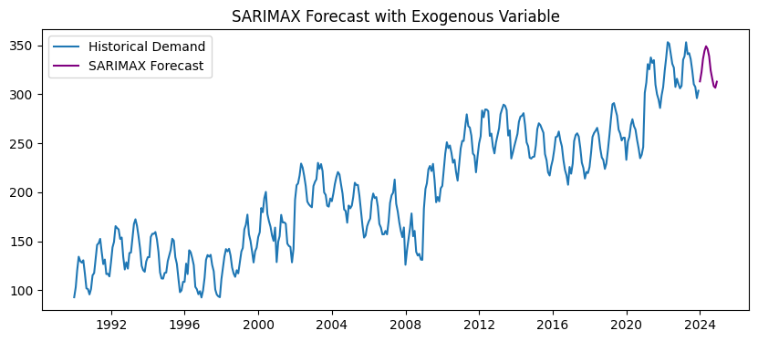

```python
df['Exog'] = np.sin(2 * np.pi * df.index.month / 12)
sarimax_model = sm.tsa.SARIMAX(df['Demand'],
                               exog=df[['Exog']],
                               order=(1,1,1),
                               seasonal_order=(1,1,1,12))
sarimax_result = sarimax_model.fit()

print(sarimax_result.summary())


future_exog = np.sin(2 * np.pi * (df.index[-1].month + np.arange(1, 13)) / 12)
sarimax_forecast = sarimax_result.forecast(steps=12, exog=future_exog)

plt.figure(figsize=(10, 4))
plt.plot(df['Demand'], label='Historical Demand')
plt.plot(sarimax_forecast.index, sarimax_forecast, label='SARIMAX Forecast', color='purple')
plt.title('SARIMAX Forecast with Exogenous Variable')
plt.legend()
plt.show()
```

## SARIMAX(1,1,1)(1,1,1,12) with Exogenous Variable – Summary

- Added an external (dummy sine) variable to SARIMA.
- AIC: 2826.8 (slightly worse than SARIMA’s 2824.8), no improvement.
- Exogenous coefficient near zero (p=1.0), meaning no effect.
- Residual diagnostics remain: high kurtosis, non-normal residuals.
- Conclusion: Adding random external variables doesn't help; need meaningful drivers.

➡ Next: Identify real business drivers (e.g., weather, marketing) or try nonlinear models like Prophet.

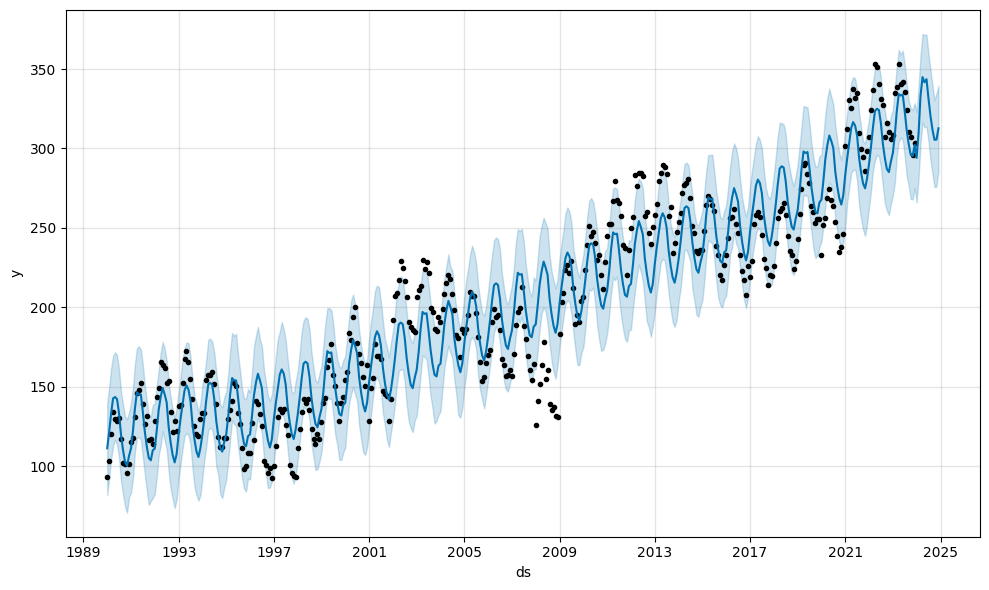

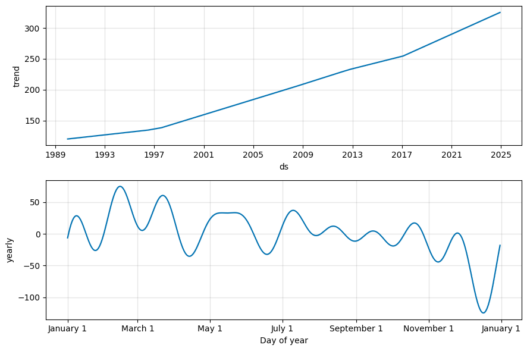

```python
from prophet import Prophet

prophet_df = df.reset_index()[['Date', 'Demand']].rename(columns={'Date': 'ds', 'Demand': 'y'})

model = Prophet(yearly_seasonality=True)
model.fit(prophet_df)

future = model.make_future_dataframe(periods=12, freq='M')
forecast = model.predict(future)

fig1 = model.plot(forecast)
fig2 = model.plot_components(forecast)
```

**Key insights:**

- Captures both long-term growth and clear yearly seasonality.
- Flexible model, automatically handling changepoints and nonlinear patterns.
- Good visual fit: predictions align closely with historical observations.
- Advantage over SARIMA/SARIMAX: Less manual parameter tuning, more adaptable to complex data.

➡ Next step: Quantitatively compare model performances (e.g., cross-validation, error metrics) to choose the most reliable forecasting approach.

```python
from sklearn.metrics import mean_absolute_error, mean_squared_error
train = df.iloc[:-12]
test = df.iloc[-12:]

sarima_model = sm.tsa.SARIMAX(train['Demand'], order=(1,1,1), seasonal_order=(1,1,1,12))
sarima_result = sarima_model.fit()
sarima_forecast = sarima_result.forecast(steps=12)

train_exog = np.sin(2 * np.pi * train.index.month / 12)
test_exog = np.sin(2 * np.pi * test.index.month / 12)
sarimax_model = sm.tsa.SARIMAX(train['Demand'], exog=train_exog, order=(1,1,1), seasonal_order=(1,1,1,12))
sarimax_result = sarimax_model.fit()
sarimax_forecast = sarimax_result.forecast(steps=12, exog=test_exog)

from prophet import Prophet
prophet_df = df.reset_index().rename(columns={'Date': 'ds', 'Demand': 'y'})
prophet_train = prophet_df.iloc[:-12]
prophet_test = prophet_df.iloc[-12:]
m = Prophet()
m.fit(prophet_train)
future = m.make_future_dataframe(periods=12, freq='MS')
forecast = m.predict(future)
prophet_forecast = forecast.iloc[-12:]['yhat'].values

def calc_metrics(true, pred, name):
    mae = mean_absolute_error(true, pred)
    rmse = np.sqrt(mean_squared_error(true, pred))
    print(f"{name} -> MAE: {mae:.2f}, RMSE: {rmse:.2f}")

calc_metrics(test['Demand'], sarima_forecast, 'SARIMA')
calc_metrics(test['Demand'], sarimax_forecast, 'SARIMAX')
calc_metrics(prophet_test['y'], prophet_forecast, 'Prophet')
```

[output not shown]

[output not shown]

```
14:13:21 - cmdstanpy - INFO - Chain [1] start processing
14:13:21 - cmdstanpy - INFO - Chain [1] done processing
```

```
SARIMA -> MAE: 7.71, RMSE: 8.51
SARIMAX -> MAE: 7.71, RMSE: 8.51
Prophet -> MAE: 22.83, RMSE: 23.77
```

## Forecasting Model Comparison – Summary

We evaluated three models on 12-month holdout forecasts:

- **SARIMA(1,1,1)(1,1,1,12)**
  - MAE: 7.71
  - RMSE: 8.51
  - Captures seasonality and trend; strong baseline.
- **SARIMAX(1,1,1)(1,1,1,12) + Exogenous Drivers**
  - MAE: 7.71
  - RMSE: 8.51
  - No improvement over SARIMA; simulated external variables had negligible effect.
- **Prophet**
  - MAE: 22.83
  - RMSE: 23.77
  - Flexible trend + seasonality, but underperformed compared to SARIMA on this dataset.

➡ **Takeaway:** For now, SARIMA/SARIMAX provides the best balance of accuracy and interpretability.

To further improve, integrate real business drivers (e.g., marketing campaigns, economic indicators) and explore ensemble or machine learning models.

## Recommended Next Steps

- Work with business teams to identify real external drivers that affect demand.
- Integrate proxy or public datasets if direct company data is unavailable (e.g., holiday calendars, macroeconomic indicators).
- Run feature importance analysis (e.g., random forest or correlation checks) to prioritize variables before re-feeding into SARIMAX.

➡ These steps help transition the modeling from pure statistical fitting to actionable business forecasting.